# Day 10 Homework

Eric Dunford

```r
#Data
data <- read.csv("Data/NAVCO_2.0.csv")
#Packages
require(dplyr)
require(MASS)
```

```r
require(ggplot2)
require(RColorBrewer)
```

#### 1. Find some relationship in your data (e.g., correlation, comparison of means, etc.) that is “significant” (don’t worry too much about what that might mean).

Looking at a simple bivariate relationship between a movements decision to provide social services and its effect on the the movement’s progress toward its stated goals.

```r
summary(data$progress)
```

```
##    Min. 1st Qu.  Median    Mean 3rd Qu.    Max.    NA's
##  0.0000  0.0000  0.0000  0.7604  1.0000  4.0000      15
```

```r
summary(data$pi_socwel)
```

```
##    Min. 1st Qu.  Median    Mean 3rd Qu.    Max.    NA's
##  0.0000  0.0000  0.0000  0.4568  1.0000  1.0000     419
```

```r
results <- summary(lm(progress~pi_socwel,data=data)) #OLS - note appropriate given the variables
results
```

```
##
## Call:
## lm(formula = progress ~ pi_socwel, data = data)
##
## Residuals:
##     Min      1Q  Median      3Q     Max
## -0.9296 -0.9296 -0.6650  0.3350  3.3350
##
## Coefficients:
##             Estimate Std. Error t value Pr(>|t|)
## (Intercept)  0.92958    0.04908  18.942  < 2e-16 ***
## pi_socwel   -0.26459    0.07261  -3.644 0.000279 ***
## ---
## Signif. codes:  0 '***' 0.001 '**' 0.01 '*' 0.05 '.' 0.1 ' ' 1
##
## Residual standard error: 1.308 on 1305 degrees of freedom
##   (419 observations deleted due to missingness)
## Multiple R-squared:  0.01007,    Adjusted R-squared:  0.009313
## F-statistic: 13.28 on 1 and 1305 DF,  p-value: 0.0002792
```

#### 2. Get an estimate of the effect size (e.g., the difference between means, or the correlation).

Let’s just look at how these two variables correlate.

```r
corr <- cor.test(data$progress,data$pi_socwel)
corr$estimate #Effect
```

```
##        cor
## -0.1003577
```

```r
corr$p.value #p-value
```

```
## [1] 0.0002791865
```

```r
corr$parameter #Degress of Freedom
```

```
##   df
## 1305
```

Movements that provide good and services for their constituencies are on average less successful in achieving their stated goals.

#### 3. Simulate data with this effect size (either using mvrnorm or adding a simulated effect), but with a much smaller data sample. In other words, simulate an underpowered study.

```r
#means and var-cov same as original data.
#Looping method
sims <- 1000
results.table <- data.frame(cor=NA,pval=NA,sim_num = 1:sims)
for(i in 1:sims){
  sim.data <- mvrnorm(100,mu=c(0.7604,0.4568),Sigma=matrix(c(1,-0.1003577,-0.1003577,1),nrow=2)) %>% as.data.frame(.)
  sim.corr <- cor.test(sim.data$V1,sim.data$V2)
  results.table[i,1] <- sim.corr$estimate
  results.table[i,2] <- sim.corr$p.value
}
summary(results.table)
```

```
##       cor                pval             sim_num
##  Min.   :-0.46676   Min.   :0.000001   Min.   :   1.0
##  1st Qu.:-0.17697   1st Qu.:0.074614   1st Qu.: 250.8
##  Median :-0.10791   Median :0.266159   Median : 500.5
##  Mean   :-0.10651   Mean   :0.343117   Mean   : 500.5
##  3rd Qu.:-0.03783   3rd Qu.:0.572531   3rd Qu.: 750.2
##  Max.   : 0.22371   Max.   :0.999434   Max.   :1000.0
```

#### 4. Examine the amount of effect-size inflation via the “significance filter” by looking at the effect sizes from the simulations, for just the sims where the effect turned out significant.

```
## stat_bin: binwidth defaulted to range/30. Use 'binwidth = x' to adjust this.
```

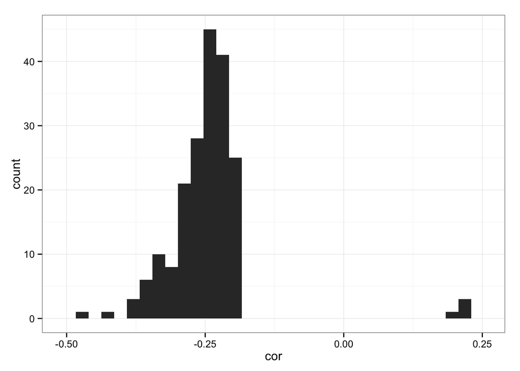

```r
alpha <- .05
sim.effect <- filter(results.table,pval < alpha)
ggplot(sim.effect,aes(x=cor)) + geom_histogram() + theme_bw()
```

```
## stat_bin: binwidth defaulted to range/30. Use 'binwidth = x' to adjust this.
```

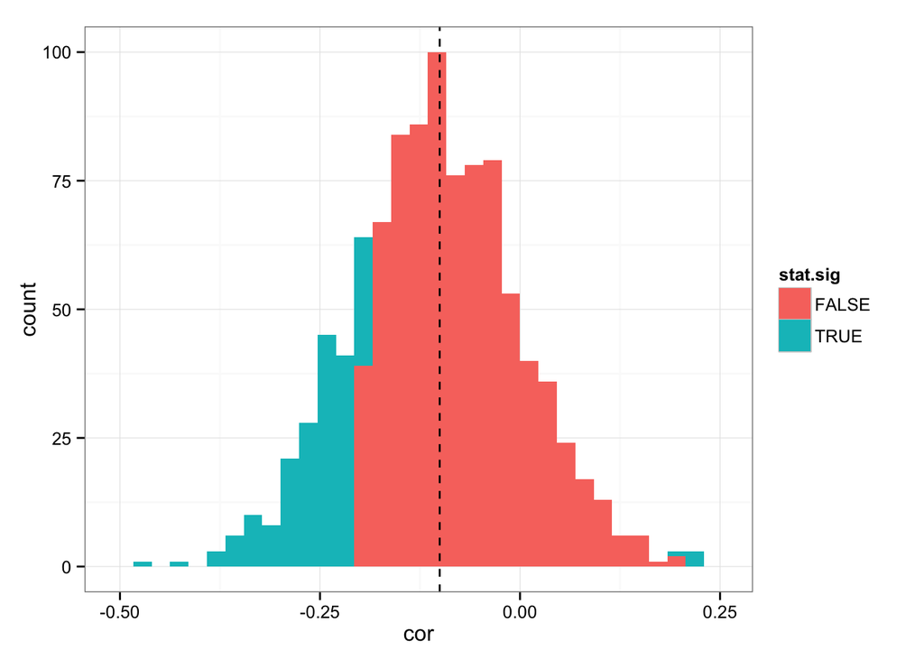

```r
#I think this is what the question is asking (similar to the practice)
results.table$stat.sig <- results.table$pval < alpha
effect.plot <- ggplot(results.table, aes(x=cor)) + geom_histogram(aes(fill = stat.sig)) +
  geom_vline(xintercept = -0.1003577, linetype = 2) + theme_bw()
effect.plot
```

```
## stat_bin: binwidth defaulted to range/30. Use 'binwidth = x' to adjust this.
## stat_bin: binwidth defaulted to range/30. Use 'binwidth = x' to adjust this.
```

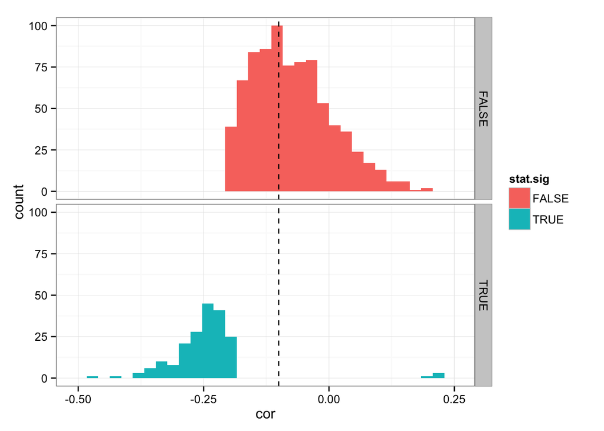

```r
effect.plot.faceted <- ggplot(results.table, aes(x=cor)) + geom_histogram(aes(fill = stat.sig)) +
  geom_vline(xintercept = -0.1003577, linetype = 2) + theme_bw() + facet_grid(stat.sig ~ .)
effect.plot.faceted
```

This is interesting. All the statistically significant results are substantively off. If the true population correlation was -.1 as it is in the data, then if we only sought out statistical significance given a low number of observations, we’d be reporting biased results… or something along those lines. Interesting! And cool way to go about thinking through this.

Let’s do the same thing but this time running the simulation with the exact same number of observations as in the data…will the results be generally the same?

```r
sims <- 1000
results.table2 <- data.frame(cor=NA,pval=NA,sim_num = 1:sims)
for(i in 1:sims){
  sim.data <- mvrnorm(1305,mu=c(0.7604,0.4568),Sigma=matrix(c(1,-0.1003577,-0.1003577,1),nrow=2)) %>% as.data.frame(.)
  sim.corr <- cor.test(sim.data$V1,sim.data$V2)
  results.table2[i,1] <- sim.corr$estimate
  results.table2[i,2] <- sim.corr$p.value
}
summary(results.table2)
```

```
##       cor                pval              sim_num
##  Min.   :-0.18630   Min.   :0.0000000   Min.   :   1.0
##  1st Qu.:-0.12028   1st Qu.:0.0000132   1st Qu.: 250.8
##  Median :-0.10046   Median :0.0002781   Median : 500.5
##  Mean   :-0.10073   Mean   :0.0110714   Mean   : 500.5
##  3rd Qu.:-0.08273   3rd Qu.:0.0027829   3rd Qu.: 750.2
##  Max.   :-0.01813   Max.   :0.5128934   Max.   :1000.0
```

```
## stat_bin: binwidth defaulted to range/30. Use 'binwidth = x' to adjust this.
## stat_bin: binwidth defaulted to range/30. Use 'binwidth = x' to adjust this.
```

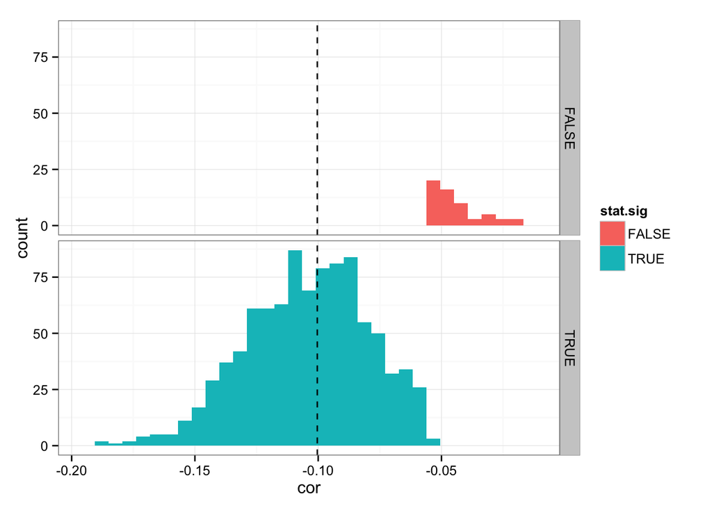

```r
results.table2$stat.sig <- results.table2$pval < alpha
effect.plot.faceted2 <- ggplot(results.table2, aes(x=cor)) + geom_histogram(aes(fill = stat.sig)) +
  geom_vline(xintercept = -0.1003577, linetype = 2) + theme_bw() + facet_grid(stat.sig ~ .)
effect.plot.faceted2
```

Neat!